# Examining Air Quality Trends in the US

Noah Hansen, Yuhan Dai, Steven Hizmi

4/19/2021

# Introduction

Since the 1960s, the US has recognized the damage pollution causes, and has been passing environmental acts ever since in an attempt to reduce harmful emissions. However, despite the increased awareness and attempts to improve air quality, it seems like the effort is quite diminishing compares to pollution from the rising population. Are the environmental restrictions and scitific breakthroughs in pollution control enough to improve air quality? Or has pollution been on the rise within the US? We argue that over time, pollution levels have improved within the US for both metro and micro-politan areas, and is due to multiple complex factors instead of a single cause.

# Data

We pulled Air Quality Index (AQI) data from [Pre-generated data files](https://aqs.epa.gov/aqsweb/airdata/download_files.html). AQI is an indicator of how dangerous current concentrations of a pollutant are. A value less than 50 is good, while over 300 is hazardous. The data is organized by CBSA, which defines metro and micro-politan areas. We use both daily and yearly summaries.

Citations:

“Air Data: Air Quality Data Collected at Outdoor Monitors Across the US”, EPA, April 15, 2021, https://www.epa.gov/outdoor-air-quality-data

“U.S. Vehicle-Miles”, Bureau of Transportation Statistics, https://www.bts.gov/content/us-vehicle-miles

### Data cleaning

For Air Quality Index (AQI) data, we combined 40 years of daily AQI data, which were in separate files. We also combine last 6 years of annual data, and filter the data for the 3 counties in Wisconsin that we decide to focus on. And then we pull separate data frames for 2019 and 2020 daily AQI data

For the US Vehicle Miles data, we transpose the dataset to rotate it so that the years are the row name that represent each entry. We then filter the data for 4 different ways of transportation that don’t have much missing data.

# Methods

The analysis primarily uses linear regression, as our intent is to discover linear trends of variables related to pollution. We do not include quadratic terms, or fit other non-linear models, as the inherent noisiness in the data would lead to overfitting and false conclusions. We also perform a hypothesis test to determine if the impact of season is significant on a pollutant. For visualization, we use scatter, line plots, and box plots.

# Results

First, we examine air quality changes from 1980 to 2019 for The US as a whole. Since there are 6 different pollutants, and many more testing sites, we take the average of the AQI values for each day. This is likely not a perfect heuristic, because a dangerous value for one pollutant should not be diminished by a safe value of another. However, if overall pollution levels change significantly it should be reflected in the mean.

#### Figure 1-A

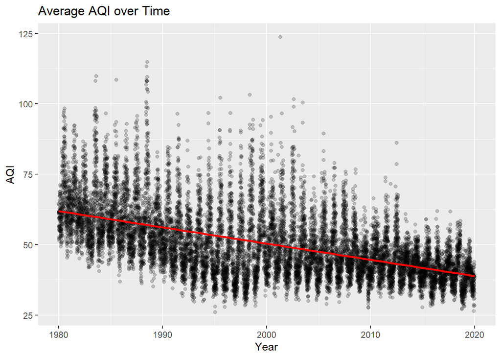

Pollution data is inherently noisy, as levels can fluctuate widely from day to day. The wind could blow a high level of pollution from one area to another or there might be a forest fire every few years that significantly increases the AQI level. For this reason, a very small percentage of the variance is explained by the model. However, the downward trend estimate of about -.55 per year (P < .001) has a small standard error. Even noisy data can have a significant trend. While -.55 is a small change in one year, over 40 years it has led to about a 22 point decrease in the average AQI level which is a significant improvement. If the trend continues, by 2060 the average will be around 17. It is also promising how the variability decreases after 2012. This suggests that extreme AQI values, which cause the most damage, are being minimized.

Some pollutant emissions are easier to reduce than others (Fig 1-B). The improvement seen in *Fig 1-A* is mainly attributed to CO, SO2, NO2. The US has made little progress in improving the concentration of particulate matter. The variability of *Fig 1-A* is likely explained by Ozone, as it’s variability goes down dramatically after 2012. What is causing this variability in the Ozone?

#### Figure 1-B

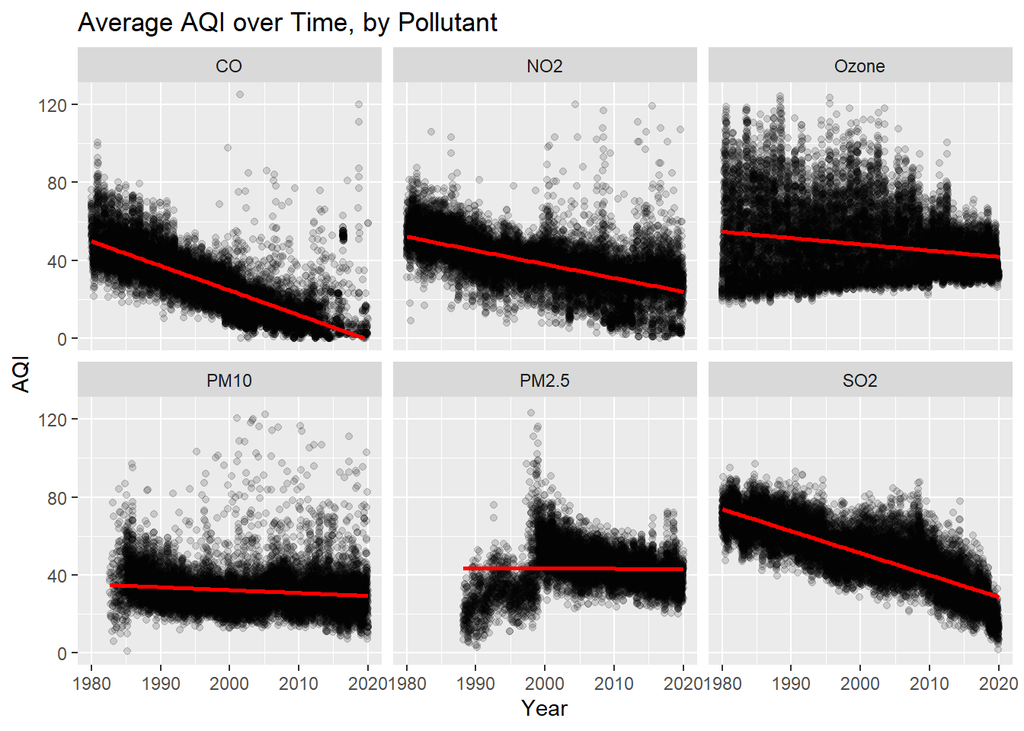

It seems like the spiking is happening in the summer (Fig 1-A), and ozone is the suspect. *Fig 1-C* motivates a hypothesis test on the difference of mean AQI values in summer months versus non-summer months. The observed difference is about 51 AQI points. The hypothesis test on mean ozone concentrations in the summer versus other seasons shows that this difference is significant (P < .001). This increase of ozone concentrations in the summer explains the some of variability in the *Fig 1-A*.

#### Figure 1-C

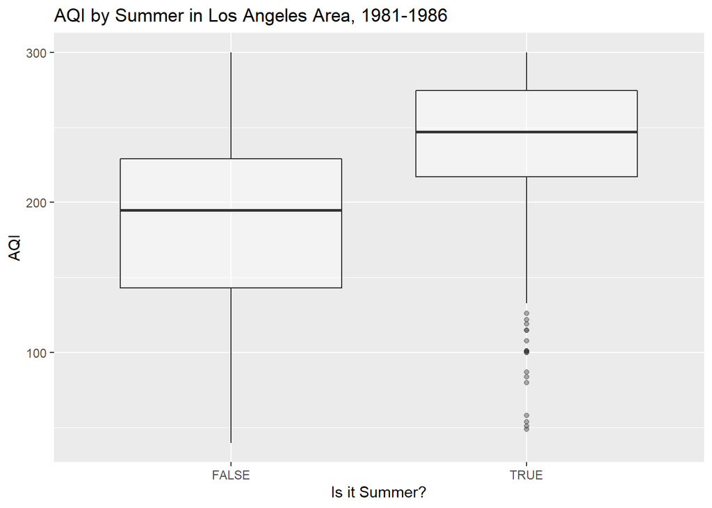

The following section groups the data by year and pollution type, then summarized the data by taking the mean of the AQI. The graph depicts the change of air quality data over the last 40 years. The horizontal line indicates the Good Level for AQI, below the line (50) means the air quality is satisfactory. The details regarding the levels of concern for AQI can be found here: https://www.airnow.gov/aqi/aqi-basics/

#### Figure 2-A

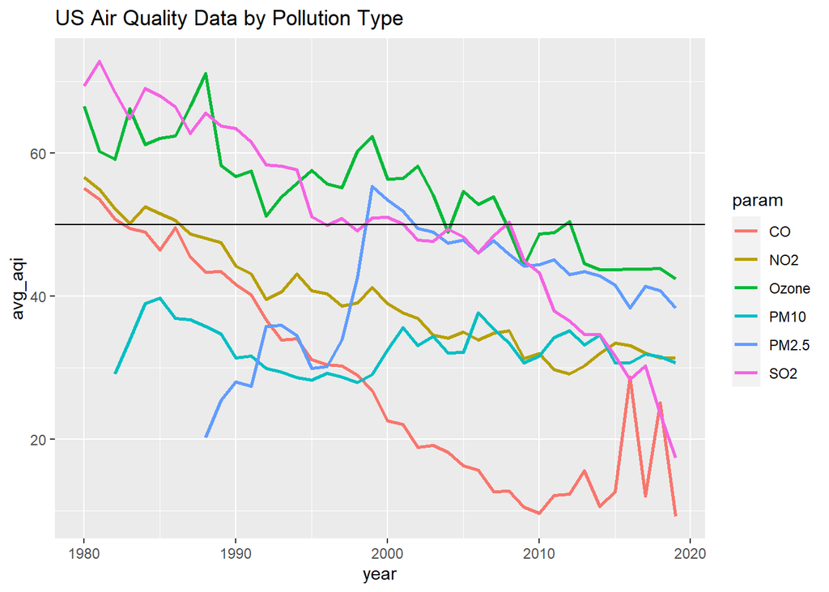

As shown above, US pollution overall is improving as the AQI level is decreasing for most of the pollution type. However, there are drastic increases or fluctuate for CO and PM2.5.

In order to understand the change, we decided to look into the main source of CO and PM2.5 fossil fuels. According to [EPA](https://www.epa.gov/), the main source of CO or PM2.5 to outdoor air are burning fossil fuels. For this part, data US vehicle miles are used to represent fossil fuel usage. The following section is to discover the trend of US vehicle miles from 1960 to 2019.

#### Figure 2-B

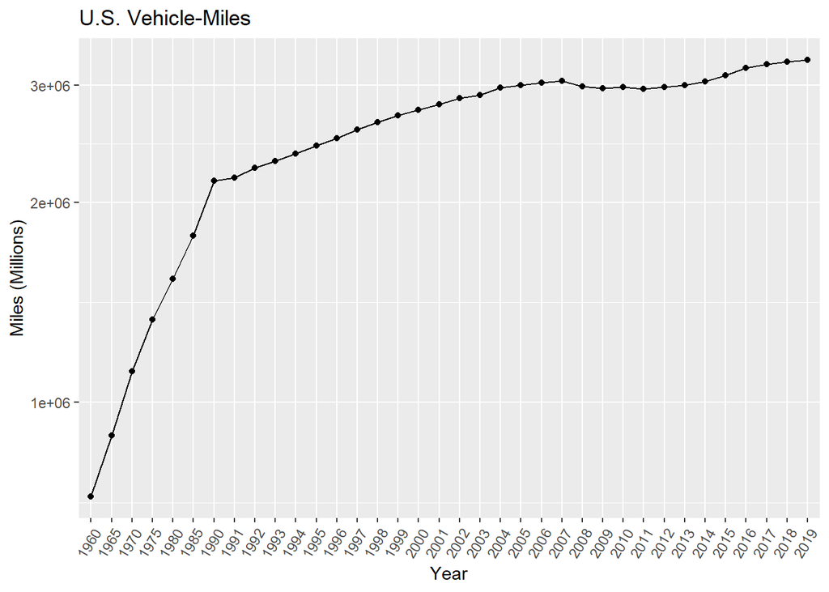

As shown above, the usage of vehicles in the US is significantly increasing over the past few decades. The steeper slope between 1960 and 1990 is due to the 5 year gaps compares to the 1 year gap between 1990 to 2019.

The following section is to perform a linear regression on CO and PM2.5 level with US vehicle miles to see if there’s a significant relation between them.

#### Figure 2-D

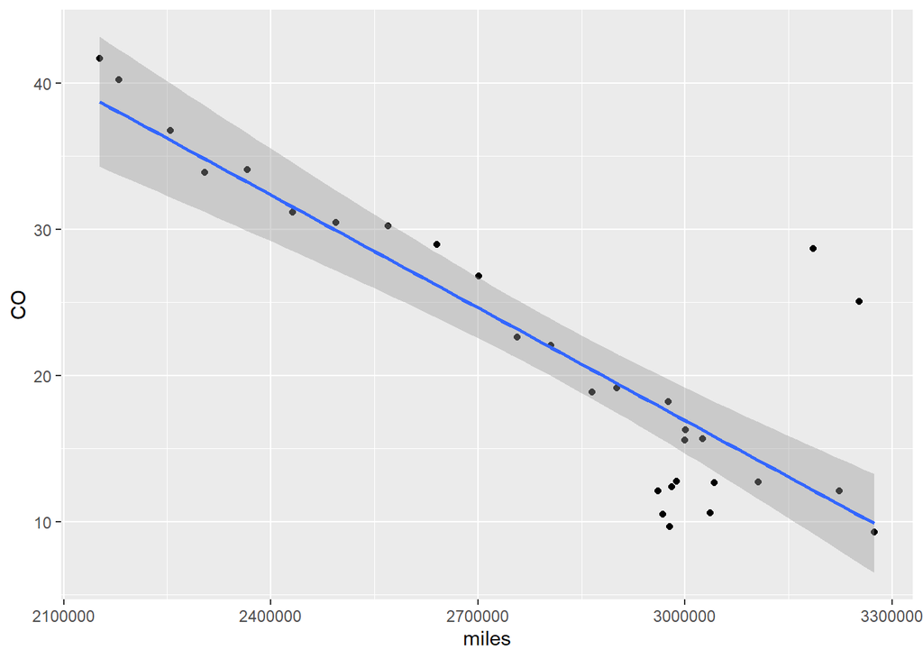

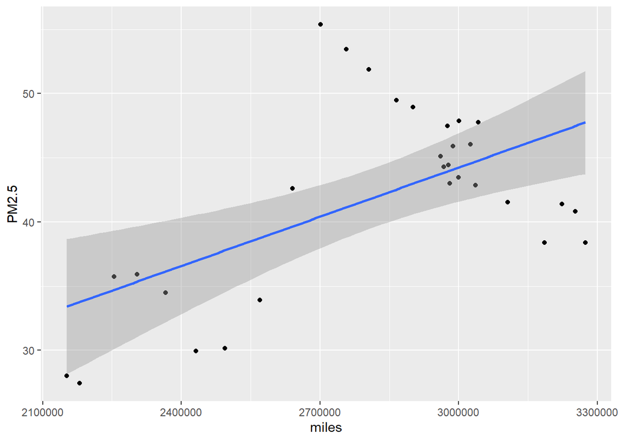

The plot may seem to be contradictory to the initial assumption which is fossil fuel use is positively related to CO and PM2.5 emission increase. However, other factors will contribute to this trend. For instance, the improved combustion efficiency of the engine may lead to less CO emission. In addition, since vehicle emission is not the only source of CO emission, the increase percentage of clean energy may also leads to the decrease of CO’s AQI level.

With the lockdown during the Covid pandemic, it gave us an opportunity to see what happened to air pollution with less human activity in three Wisconsin counties: Dane, Milwaukee, and Waukesha. So we used the collected county data over the last 6 years to compare with data during the lockdown. We also looked into data from 2020, from January to June (as that is the most updated data out there thus far).

#### Figure 3-A

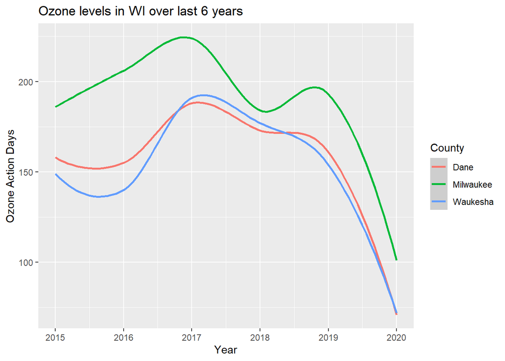

#### Figure 3-B

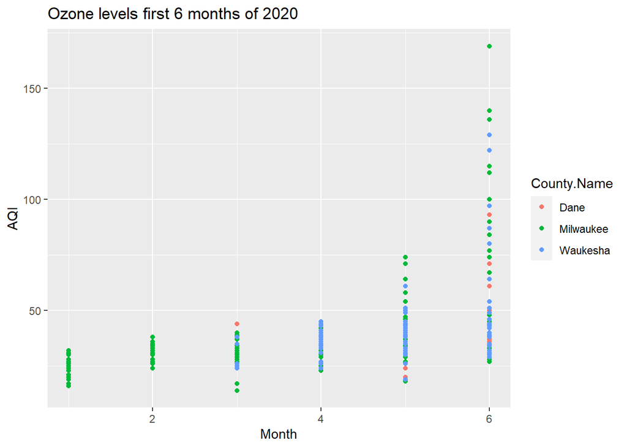

Considering that the first lockdown in Wisconsin was March, the ozone levels don’t go beyond 50, which is deemed safe. The ozone levels don’t start increasing until May and June, which is to be expected as Ozone levels increase during summer. The question is: Did Covid have an affect on the Ozone levels or was it increased due to it being summer? To see which is true, we decided to look at the daily data from 2019, with no stay at home orders to see how they compare.